# Real-data disturbance–response V — C–Q wavelet synchrony (nitrate concentration → discharge)

The Analysis IV wavelet, moved to the noisier concentration–discharge coupling — nitrate is only partly set by flow, a less-causal, higher-noise test of the method (native-cadence grids, shared physical-time axis)

nic (nic@cascadeclimate.org)

2026-07-18

This is **Analysis IV’s method — Morlet wavelet coherence via WaveletComp — moved to the concentration–discharge (C–Q) relationship**: driver = discharge `Q`, response = **stream nitrate concentration `C`**. Where the P→Q coupling (III/IV) is close to causal — rain drives flow — the C–Q coupling is **partial and noisier**: nitrate concentration is only *partly* set by flow (dilution vs flushing, catchment sources, hysteresis, and — at two of these sites — a chemical manipulation acting directly on nitrate). So this is the real test the study has been building toward: **how does the wavelet read a genuinely weaker, less-deterministic coupling?**

Both channels are analyzed in **log space** — the standard C–Q power-law framing (`log C = a + b·log Q`), so `climate = log(Q)`, `log_response = log(C)`. The pre-fit predictor’s slope below *is* that C–Q exponent `b` (≈0 ⇒ chemostatic / well-buffered; ≠0 ⇒ chemodynamic).

**Sampling & the shared axis.** Nitrate is grab-sampled (weekly to ~3-weekly), so — rather than fabricate a common fine grid — each site runs on **its own native-cadence grid** (bin = `step_days`, built in `prep_ms_series.Rmd`); the wavelet runs in those native steps and every period/lag is rescaled to **physical days** (`× step_days`) so all four panels share one period-in-days axis and one annual band. The cost is honest: a coarser-sampled site cannot resolve short periods — **hjandrews (21-day steps) goes blank below ~3 months** — and the **percent of interpolated (no-sample) bins** is reported on every panel. `MC06` is excluded (its nitrate is 44% empty months with a ~4-year gap — a wavelet there would read interpolation).

Four band-localized quantities, all read at the physical **annual band (`P≈365 d`)**: wavelet **coherence** (normalized), **cross-power** (un-normalized), **phase → apparent lag** (days), and **amplitude ratio** `C/Q`. *Same caveats as IV:* COI/edge buffering (`EF ≈ √2·annual` in each site’s steps), and block SEs (one estimate per annual cycle; circular for phase).

## Helpers

```r
# All wavelet helpers now live in R/wavelet_kernel.R (sourced in setup) — edit once, not three
# times. Build THIS notebook's copies from a small config and inject them into the chunk
# environment, so every call site below stays bare (wco(df, step), band_trace(wc, df, step), ...).
# Config = the real C–Q leg: annual band (P = 365 DAYS) read on each site's NATIVE step grid, so
# `step` (= step_days) is passed per site and every period/lag is rescaled to days; a date axis;
# calendar-quarter shading; the period axis is relabelled to days via spec.period.axis. No phase
# gating (the driver here is log Q, which does oscillate annually). channel meaning: climate = log Q,
# log_response = log C — the code is identical. See tickets/wavelet_significance_mask.plan.md.
list2env(make_wavelet_kernel(list(
  P_days         = P_DAYS,                       # 365 — annual band in DAYS; step converts to native bins
  phase_gate     = FALSE,
  has_transition = FALSE,                        # real phases are pre / disturbance / post
  season         = TRUE,
  trace_x        = "date",                        # native grids differ ⇒ plot on the shared calendar axis
  lag_wrap_break = FALSE,
  lag_lab        = "app. lag (d)",
  smooth_w       = function(step) round(90 / step),   # ~90-day resid-derivative window, in native bins
  lowerPeriod    = 4,                             # 4 steps ≈ 4·step_days (WaveletComp coherence floor)
  upperPeriod    = function(P, df) floor(nrow(df) / 3),  # WaveletComp's natural COI-safe scale limit
  wc_marks       = c("3 mo" = 91, "1 yr" = 365, "2 yr" = 730),
  spec_axis      = TRUE,                           # relabel the native-step period axis to physical days
  dist_vline     = "grey70",
  timelab        = "time (bins)", periodlab = "period",
  resp_lab       = "C", drv_lab = "log(Q)",
  resid_ylab     = "residual = log(C) − predicted (green)",
  resid_sec      = "d(residual)/dt (smoothed, orange)",
  resid_sub      = function(g, L, step)
    sprintf("pre-fit C–Q predictor:  log(C)(t) ≈ %.2f · log(Q)(t − %d bins ≈ %d d)   [slope = C–Q exponent b]",
            g, L, L * step)
)), environment())
```

```
## <environment: R_GlobalEnv>
```

```r
# per-site provenance line (n, cadence, % interpolated) — 05-only, kept notebook-local (not a
# shared wavelet helper; it is a provenance formatter for the C–Q panels).
prov_line <- function(d) sprintf(
  "**n = %d bins** (pre %d / post %d) · native step **%d d** · **%.0f%% of bins interpolated** (no NO3 sample).",
  nrow(d), sum(d$phase == "pre"), sum(d$phase == "post"), d$step_days[1], 100 * mean(d$C_interp))
```

```r
sites <- c("hbef_w1", "hjandrews_GSWS10", "fernow_WS-3", "fernow_WS-5")   # MC06 dropped (see intro)
D <- lapply(sites, function(s)
  read_csv(sprintf("%s__cq_native.csv", s), show_col_types = FALSE) %>%
    mutate(phase = factor(phase, c("pre", "disturbance", "post")),
           climate = log(Q), log_response = log(C)))          # C–Q log–log
names(D) <- sites
STEP <- setNames(vapply(D, function(d) d$step_days[1], numeric(1)), sites)
qd <- read_csv("../qualifying_disturbances.csv", show_col_types = FALSE) %>%
  mutate(site = paste0(domain, "_", site_code))
label <- setNames(sprintf("%s (%s, %s)", qd$site, qd$disturbance, qd$class), qd$site)
```

```r
# One coherency transform per site (native steps), reused by every image/trace/table.
WC <- Map(wco, D, STEP)
TR <- Map(band_trace, WC, D, STEP)
SM <- Map(wave_summary, TR, STEP)
```

## Data provenance (nitrate coverage)

Nitrate `n`, native cadence, and interpolated-bin fraction per site — the honest resolution each C–Q wavelet rests on. Discharge is fully observed; the interpolation is all on the nitrate side.

```r
prov <- bind_rows(lapply(D, function(d) tibble(
  site = d$site[1], step_days = d$step_days[1], n_bins = nrow(d),
  pre = sum(d$phase == "pre"), post = sum(d$phase == "post"),
  C_interp_pct = round(100 * mean(d$C_interp), 1))))
cat(kable(prov, caption = "Per-site C–Q grid: native step, n bins, pre/post split, % interpolated (no-sample) bins."), sep = "\n")
```

Per-site C–Q grid: native step, n bins, pre/post split, % interpolated (no-sample) bins.

| site | step_days | n_bins | pre | post | C_interp_pct |
| --- | --- | --- | --- | --- | --- |
| hbef_w1 | 7 | 2035 | 835 | 1200 | 5.7 |
| hjandrews_GSWS10 | 21 | 747 | 174 | 573 | 3.3 |
| fernow_WS-3 | 7 | 1928 | 311 | 1617 | 20.8 |
| fernow_WS-5 | 7 | 1473 | 835 | 625 | 9.0 |

# Where the shared C–Q power lives

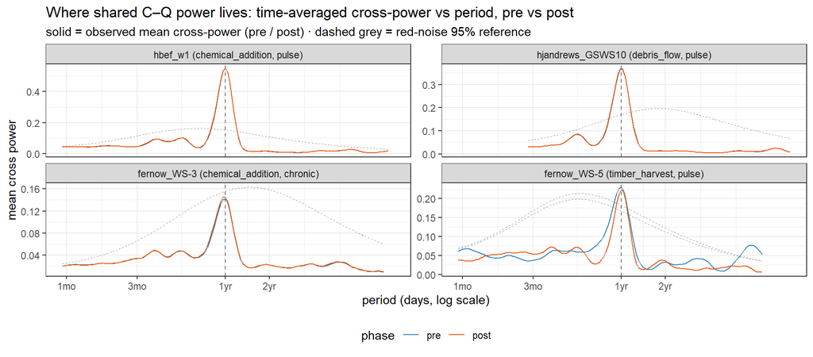

```r
# Split PRE vs POST (EF-buffered settled windows); step is per site. kernel returns id/phase/period/power/ref.
xps <- bind_rows(Map(function(wc, df, id, step) xpower_spectrum(wc, df, id, step, split = TRUE),
                     WC, D, names(WC), STEP)) %>% mutate(id = factor(id, sites))
ggplot(xps, aes(period, power, colour = phase)) +
  geom_vline(xintercept = P_DAYS, linetype = 2, colour = "grey45") +
  geom_line(aes(period, ref, group = phase), colour = "grey55", linetype = 2, linewidth = 0.3) +  # red-noise 95%, per phase
  geom_line(linewidth = 0.5) +
  facet_wrap(~ id, scales = "free_y", labeller = as_labeller(label)) +   # strip = site + disturbance (matches section headers)
  scale_colour_manual(values = c(pre = "#3182bd", post = "#e6550d")) +
  scale_x_log10(breaks = c(30, 91, 365, 730), labels = c("1mo", "3mo", "1yr", "2yr")) +
  labs(title = "Where shared C–Q power lives: time-averaged cross-power vs period, pre vs post",
       subtitle = "solid = observed mean cross-power (pre / post) · dashed grey = red-noise 95% reference",
       colour = "phase", x = "period (days, log scale)", y = "mean cross power")
```

# hbef_w1 — chemical addition (pulse) · Ca

The best-sampled site (near-weekly, ~6% interpolated). The Ca (wollastonite) addition acts on watershed chemistry, so pre/post nitrate coupling is squarely in scope here.

```r
cat(prov_line(D[["hbef_w1"]]))
```

**n = 2035 bins** (pre 835 / post 1200) · native step **7 d** · **6% of bins interpolated** (no NO3 sample).

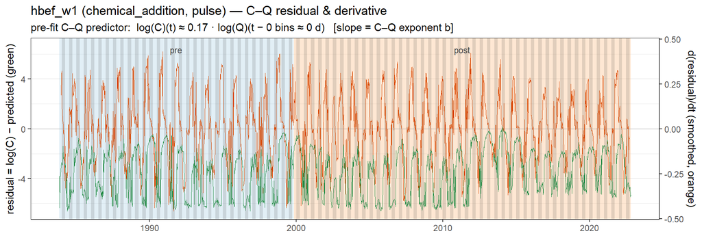

Figure 2. hbef_w1 — C–Q model residual (green) + smoothed derivative (orange); phases shaded, dashed = disturbance. Subtitle gives the pre-fit C–Q exponent b.

```r
plot_resid(D[["hbef_w1"]], paste(label["hbef_w1"], "— C–Q residual & derivative"), STEP["hbef_w1"])
```

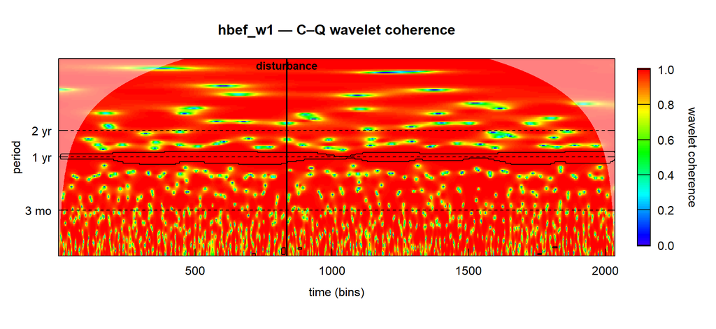

Figure 3. hbef_w1 — C–Q wavelet coherence (time × period, period in days via the native step). Dashed guides = season / year / 2-year.

```r
plot_wc(WC[["hbef_w1"]], D[["hbef_w1"]], "hbef_w1 — C–Q wavelet coherence", STEP["hbef_w1"])
```

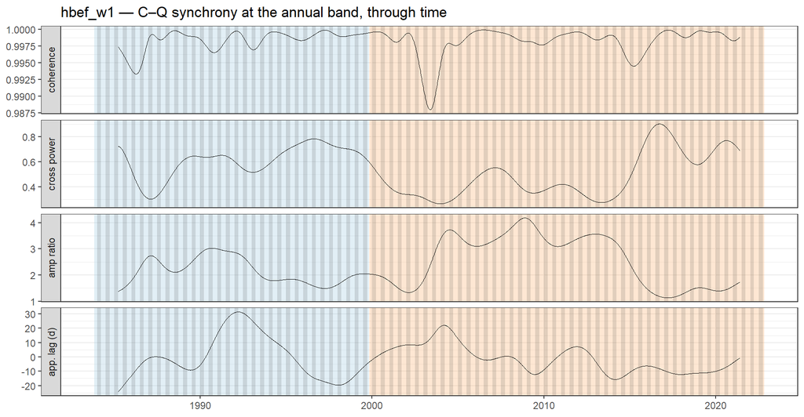

Figure 4. hbef_w1 — annual-band C–Q metrics through time; COI edges blanked, phases shaded.

```r
plot_band_trace(TR[["hbef_w1"]], "hbef_w1 — C–Q synchrony at the annual band, through time")
```

```r
emit_table(SM[["hbef_w1"]], "hbef_w1 — C–Q band synchrony, settled pre vs post")
```

hbef_w1 — C–Q band synchrony, settled pre vs post

| phase | n_blocks | coherence | xpower | amp_ratio | phi | lag |
| --- | --- | --- | --- | --- | --- | --- |
| pre | 38 | 1 | 0.53 | 2.36 | -0.02 | -0.93 |
| post | 38 | 1 | 0.54 | 2.35 | -0.04 | -2.26 |

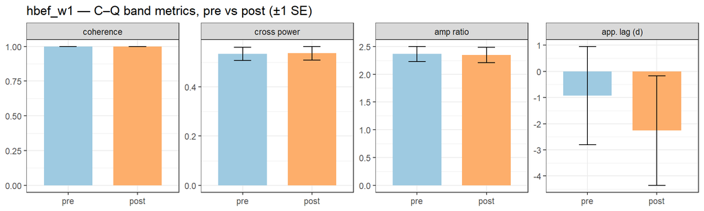

Figure 5. hbef_w1 — pre vs post C–Q band metrics, ±1 SE.

```r
plot_wave_bars(SM[["hbef_w1"]], "hbef_w1 — C–Q band metrics, pre vs post (±1 SE)")
```

# hjandrews_GSWS10 — debris flow (pulse)

The coarsest grid (~3-weekly), so this panel is **blank below ~3 months** — an honest limit of its sampling. A physical channel disturbance; watch whether the annual-band C–Q amplitude/lag shift.

```r
cat(prov_line(D[["hjandrews_GSWS10"]]))
```

**n = 747 bins** (pre 174 / post 573) · native step **21 d** · **3% of bins interpolated** (no NO3 sample).

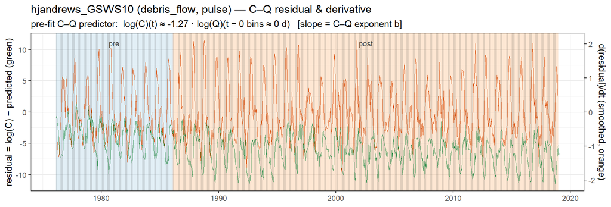

Figure 6. hjandrews_GSWS10 — C–Q residual (green) + derivative (orange); phases shaded, dashed = disturbance.

```r
plot_resid(D[["hjandrews_GSWS10"]], paste(label["hjandrews_GSWS10"], "— C–Q residual & derivative"), STEP["hjandrews_GSWS10"])
```

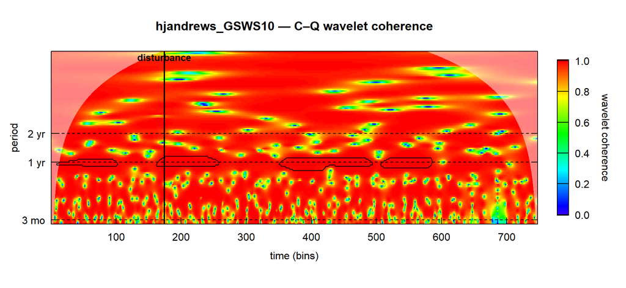

Figure 7. hjandrews_GSWS10 — C–Q wavelet coherence. Blank below ~3 months (21-day sampling).

```r
plot_wc(WC[["hjandrews_GSWS10"]], D[["hjandrews_GSWS10"]], "hjandrews_GSWS10 — C–Q wavelet coherence", STEP["hjandrews_GSWS10"])
```

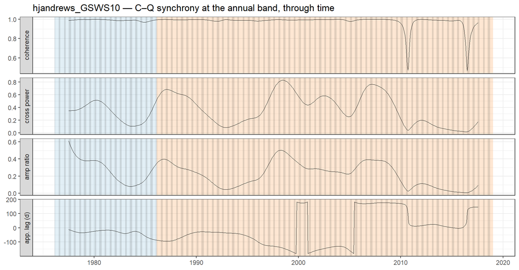

Figure 8. hjandrews_GSWS10 — annual-band C–Q metrics through time.

```r
plot_band_trace(TR[["hjandrews_GSWS10"]], "hjandrews_GSWS10 — C–Q synchrony at the annual band, through time")
```

```r
emit_table(SM[["hjandrews_GSWS10"]], "hjandrews_GSWS10 — C–Q band synchrony, settled pre vs post")
```

hjandrews_GSWS10 — C–Q band synchrony, settled pre vs post

| phase | n_blocks | coherence | xpower | amp_ratio | phi | lag |
| --- | --- | --- | --- | --- | --- | --- |
| pre | 43 | 0.98 | 0.36 | 0.23 | -1.31 | -75.88 |
| post | 43 | 0.98 | 0.36 | 0.25 | -1.15 | -66.76 |

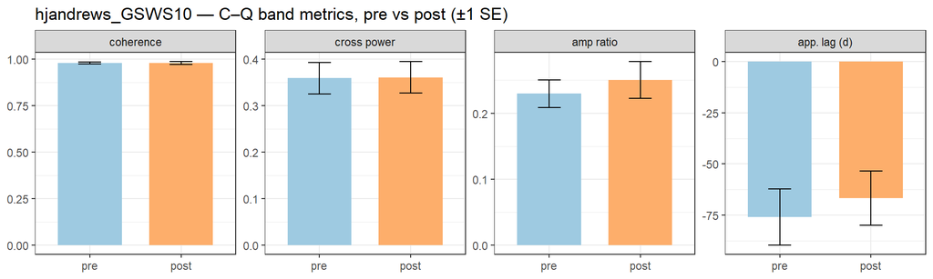

Figure 9. hjandrews_GSWS10 — pre vs post C–Q band metrics, ±1 SE.

```r
plot_wave_bars(SM[["hjandrews_GSWS10"]], "hjandrews_GSWS10 — C–Q band metrics, pre vs post (±1 SE)")
```

# fernow_WS-3 — chemical addition (chronic) · acidification

Chronic (NH₄)₂SO₄ acidification since 1989 — an *ongoing* manipulation acting directly on stream nitrogen, so “post” is an actively-forced regime. One flagged multi-month nitrate gap (~21% interpolated overall).

```r
cat(prov_line(D[["fernow_WS-3"]]))
```

**n = 1928 bins** (pre 311 / post 1617) · native step **7 d** · **21% of bins interpolated** (no NO3 sample).

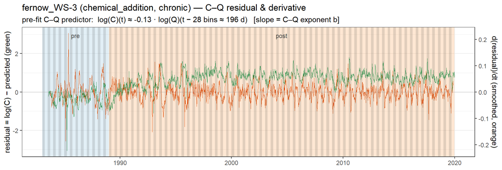

Figure 10. fernow_WS-3 — C–Q residual (green) + derivative (orange); phases shaded, dashed = disturbance.

```r
plot_resid(D[["fernow_WS-3"]], paste(label["fernow_WS-3"], "— C–Q residual & derivative"), STEP["fernow_WS-3"])
```

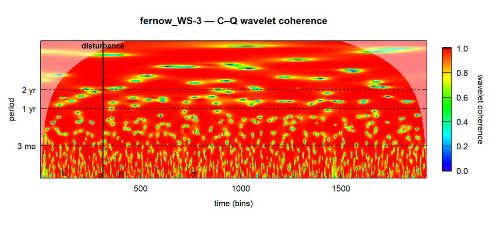

Figure 11. fernow_WS-3 — C–Q wavelet coherence.

```r
plot_wc(WC[["fernow_WS-3"]], D[["fernow_WS-3"]], "fernow_WS-3 — C–Q wavelet coherence", STEP["fernow_WS-3"])
```

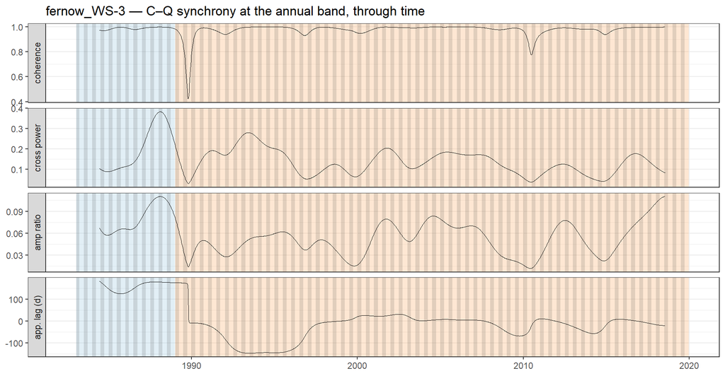

Figure 12. fernow_WS-3 — annual-band C–Q metrics through time.

```r
plot_band_trace(TR[["fernow_WS-3"]], "fernow_WS-3 — C–Q synchrony at the annual band, through time")
```

```r
emit_table(SM[["fernow_WS-3"]], "fernow_WS-3 — C–Q band synchrony, settled pre vs post")
```

fernow_WS-3 — C–Q band synchrony, settled pre vs post

| phase | n_blocks | coherence | xpower | amp_ratio | phi | lag |
| --- | --- | --- | --- | --- | --- | --- |
| pre | 36 | 0.98 | 0.14 | 0.06 | -0.31 | -17.83 |
| post | 36 | 0.98 | 0.14 | 0.06 | -0.39 | -22.79 |

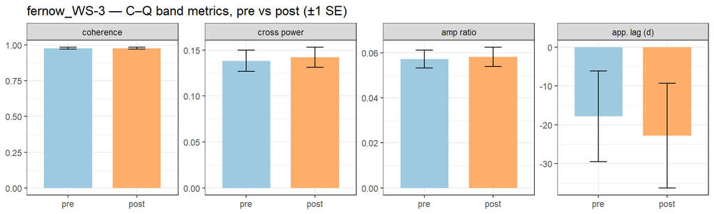

Figure 13. fernow_WS-3 — pre vs post C–Q band metrics, ±1 SE.

```r
plot_wave_bars(SM[["fernow_WS-3"]], "fernow_WS-3 — C–Q band metrics, pre vs post (±1 SE)")
```

# fernow_WS-5 — timber harvest (pulse)

The clearcut is the classic nitrate-export disturbance — forest removal releases nitrate, so a C–Q change across 2007 is plausible here. One flagged multi-month gap (~9% interpolated).

```r
cat(prov_line(D[["fernow_WS-5"]]))
```

**n = 1473 bins** (pre 835 / post 625) · native step **7 d** · **9% of bins interpolated** (no NO3 sample).

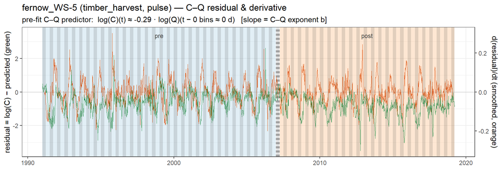

Figure 14. fernow_WS-5 — C–Q residual (green) + derivative (orange); phases shaded, dashed = disturbance.

```r
plot_resid(D[["fernow_WS-5"]], paste(label["fernow_WS-5"], "— C–Q residual & derivative"), STEP["fernow_WS-5"])
```

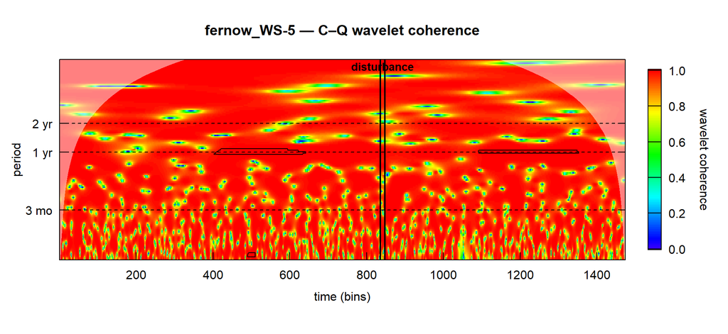

Figure 15. fernow_WS-5 — C–Q wavelet coherence.

```r
plot_wc(WC[["fernow_WS-5"]], D[["fernow_WS-5"]], "fernow_WS-5 — C–Q wavelet coherence", STEP["fernow_WS-5"])
```

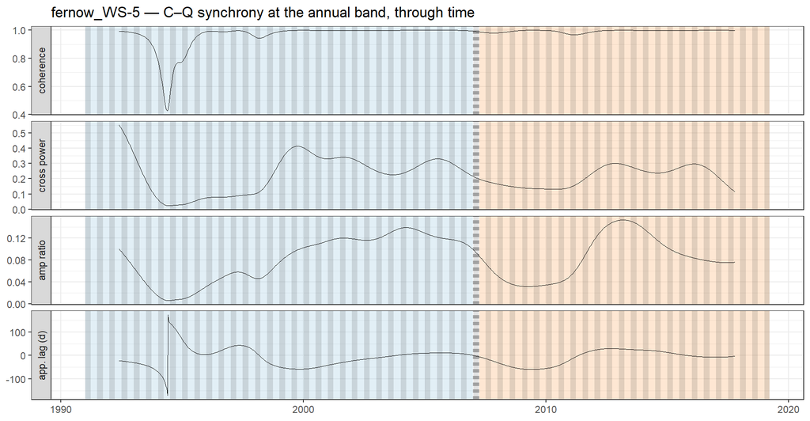

Figure 16. fernow_WS-5 — annual-band C–Q metrics through time.

```r
plot_band_trace(TR[["fernow_WS-5"]], "fernow_WS-5 — C–Q synchrony at the annual band, through time")
```

```r
emit_table(SM[["fernow_WS-5"]], "fernow_WS-5 — C–Q band synchrony, settled pre vs post")
```

fernow_WS-5 — C–Q band synchrony, settled pre vs post

| phase | n_blocks | coherence | xpower | amp_ratio | phi | lag |
| --- | --- | --- | --- | --- | --- | --- |
| pre | 14 | 0.96 | 0.23 | 0.08 | -0.17 | -9.79 |
| post | 10 | 1.00 | 0.21 | 0.09 | -0.07 | -3.94 |

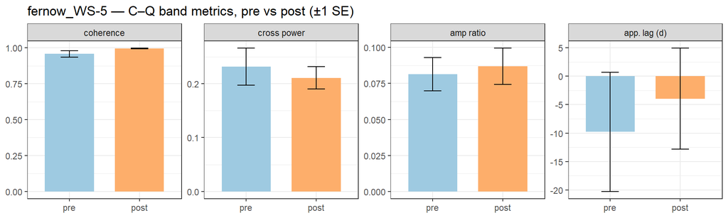

Figure 17. fernow_WS-5 — pre vs post C–Q band metrics, ±1 SE.

```r
plot_wave_bars(SM[["fernow_WS-5"]], "fernow_WS-5 — C–Q band metrics, pre vs post (±1 SE)")
```

# Cross-site summary

Post-minus-pre change in the four C–Q band metrics per site, each Δ with its propagated SE. All sites share the physical annual band and identical metric scales, so they compare directly despite different native grids.

```r
sm_all <- bind_rows(SM, .id = "site")
delta <- metrics_long(sm_all, c("site", "phase")) %>%
  pivot_wider(names_from = phase, values_from = c(value, se)) %>%
  mutate(delta = value_post - value_pre, delta_se = sqrt(se_pre^2 + se_post^2),
         site = factor(site, sites))
```

```r
cat(kable(delta %>% transmute(site, metric = metric_labs[as.character(metric)],
                              pre = value_pre, post = value_post, delta, delta_se),
          digits = 2, caption = "pre → post change in C–Q band metrics, all sites (delta_se = propagated ±1 SE)"), sep = "\n")
```

pre → post change in C–Q band metrics, all sites (delta_se = propagated ±1 SE)

| site | metric | pre | post | delta | delta_se |
| --- | --- | --- | --- | --- | --- |
| hbef_w1 | coherence | 1.00 | 1.00 | 0.00 | 0.00 |
| hbef_w1 | cross power | 0.53 | 0.54 | 0.00 | 0.04 |
| hbef_w1 | amp ratio | 2.36 | 2.35 | -0.02 | 0.19 |
| hbef_w1 | app. lag (d) | -0.93 | -2.26 | -1.33 | 2.81 |
| hjandrews_GSWS10 | coherence | 0.98 | 0.98 | 0.00 | 0.01 |
| hjandrews_GSWS10 | cross power | 0.36 | 0.36 | 0.00 | 0.05 |
| hjandrews_GSWS10 | amp ratio | 0.23 | 0.25 | 0.02 | 0.03 |
| hjandrews_GSWS10 | app. lag (d) | -75.88 | -66.76 | 9.12 | 19.04 |
| fernow_WS-3 | coherence | 0.98 | 0.98 | 0.00 | 0.01 |
| fernow_WS-3 | cross power | 0.14 | 0.14 | 0.00 | 0.02 |
| fernow_WS-3 | amp ratio | 0.06 | 0.06 | 0.00 | 0.01 |
| fernow_WS-3 | app. lag (d) | -17.83 | -22.79 | -4.96 | 17.84 |
| fernow_WS-5 | coherence | 0.96 | 1.00 | 0.04 | 0.02 |
| fernow_WS-5 | cross power | 0.23 | 0.21 | -0.02 | 0.04 |
| fernow_WS-5 | amp ratio | 0.08 | 0.09 | 0.01 | 0.02 |
| fernow_WS-5 | app. lag (d) | -9.79 | -3.94 | 5.84 | 13.74 |

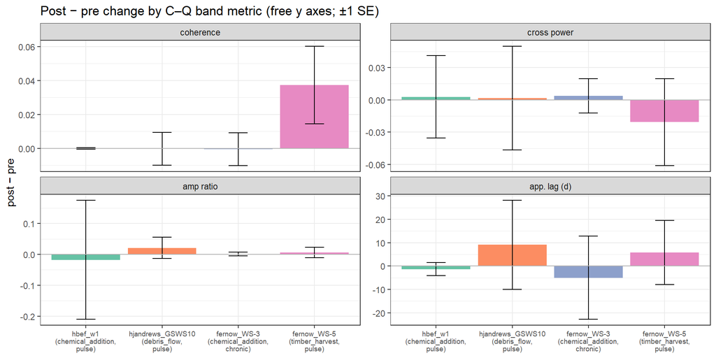

Figure 18. Post − pre change per site, faceted by band metric (free y), ±1 propagated SE. The C–Q read against P–Q (Analysis IV): a noisier, weaker coupling.

```r
# x-axis labels = site + disturbance (the `label` vector), wrapped to fit; matches the section headers.
sitelab <- function(s) vapply(s, function(x) paste(strwrap(label[[x]], 17), collapse = "\n"), character(1))
ggplot(delta, aes(site, delta, fill = site)) +
  geom_col() +
  geom_errorbar(aes(ymin = delta - delta_se, ymax = delta + delta_se), width = 0.25, colour = "black", na.rm = TRUE) +
  geom_hline(yintercept = 0, colour = "grey70") +
  facet_wrap(~ metric, scales = "free_y", labeller = as_labeller(metric_labs)) +
  scale_fill_brewer(palette = "Set2", guide = "none") +
  scale_x_discrete(labels = sitelab) +
  labs(title = "Post − pre change by C–Q band metric (free y axes; ±1 SE)", x = NULL, y = "post − pre") +
  theme(axis.text.x = element_text(size = 7))
```

**Takeaways — the wavelet on a less-causal coupling.** Read against Analysis IV (P→Q): rainfall drives discharge almost mechanically, and there the normalized coherence saturated near 1 while cross-power/amplitude carried the story. C–Q is the harder case the study was built to reach — nitrate is only *partly* set by flow. The pre-fit exponent `b` (each residual subtitle) says whether a site is near-chemostatic (`b≈0`, nitrate roughly flow-independent) or chemodynamic; the band metrics say whether even that partial coupling is *seasonally organized* and whether the disturbance — especially the two that hit nitrogen directly (hbef Ca, fernow WS-3 acidification) — reshapes it. Where P→Q’s discharge channel was near-silent at the chemistry sites, C–Q is exactly where a signal *can* live. The method’s limits carry over intact: coherence remains the least trustworthy channel, the honest resolution is set by each site’s sampling (reported per panel), and a coarser record simply cannot see short periods — shown, not hidden. ```